# Study 1

## (1) Description of Data

The posted data for this study consists of 1 compiled, deidentified data file. Two (2) responses were excluded because it was not possible to accurately match their separate questionnaire sheets, as described in the main text of the article.

## (2) Descriptive Statistics

**Total *N*:**

- **Whole sample:** 276
- *N* who completed Questionnaire A: 180
- *N* who completed Questionnaire B: 251

**Sensitivity analyses:** These completion rates provided a statistical power of .80 to detect effects of |*r*| >= 0.21 and 0.18.

**Percentage by gender:**

```
## gender
## female   male   <NA>
##    156    120      0
```

*M*s and *SD*s:

```
##           n  mean   sd
## Age     276 18.78 1.10
## rfa     173  0.03 0.72
## rfapro  174  5.50 0.86
## rfapre  173  5.47 0.96
## rfh     161  0.15 0.68
## rfhpro  165  4.70 1.19
## rfhpre  164  4.51 1.08
## rfr     162  0.18 0.83
## rfrpro  165  5.14 1.00
## rfrpre  162  4.96 1.02
## rfq     241  0.50 0.98
## rfqpro  246  3.86 0.61
## rfqpre  242  3.36 0.89
## achieve 175  5.82 1.07
## respons 176  4.75 1.17
```

**Alphas:**

- **Identity-specific motivation-academics promotion:** 0.71
- **Identity-specific motivation-academics prevention:** 0.72
- **Identity-specific motivation-health promotion:** 0.83
- **Identity-specific motivation-health prevention:** 0.67
- **Identity-specific motivation-relationship promotion:** 0.72
- **Identity-specific motivation-relationship prevention:** 0.64
- **RFQ promotion:** 0.67
- **RFQ prevention:** 0.79
- **Achievement motives:** 0.85
- **Responsibility motives:** 0.66

## (3) Zero-Order and Disattenuated Correlations

**Pairwise correlations:**

```
##         lower    r upper     p  df
## rfa-rfh  0.03 0.18  0.33 0.020 159
## rfa-rfr  0.01 0.16  0.31 0.043 160
## rfa-rfq -0.03 0.14  0.29 0.104 143
## rfh-rfr  0.01 0.16  0.31 0.041 154
## rfh-rfq -0.17 0.00  0.17 0.969 132
## rfr-rfq  0.04 0.21  0.36 0.016 132
```

**Disattenuated correlations (above the horizontal; pairwise below the horizontal, alphas on the horizontal):**

```
##      rfa  rfh  rfr  rfq
## rfa 0.83 0.22 0.19 0.17
## rfh 0.18 0.87 0.20 0.00
## rfr 0.16 0.16 0.81 0.27
## rfq 0.14 0.00 0.21 0.73
```

## (4) Factor Analyses

**Scree plot:**

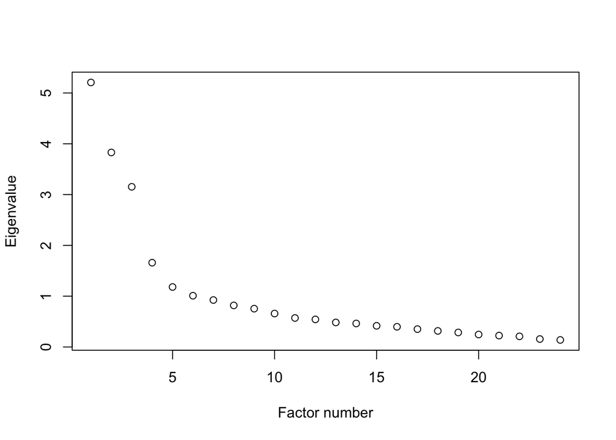

**Eigenvalues:**

```
##  [1] 5.21 3.83 3.15 1.66 1.18 1.01 0.92 0.82 0.75 0.66 0.57 0.54 0.48 0.46 0.42 0.40 0.35 0.32 0.29
## [20] 0.25 0.22 0.21 0.16 0.14
```

**Factor analysis results:**

```
##
## Loadings:
##         Factor1 Factor2 Factor3
## RFApro2  0.038   0.544   0.033
## RFApro3  0.041   0.822   0.075
## RFApro4  0.149   0.317  -0.086
## RFApro5  0.133   0.664   0.232
## RFApre1 -0.052   0.554  -0.006
## RFApre2  0.009   0.538   0.093
## RFApre3 -0.023   0.733  -0.003
## RFApre5  0.009   0.717   0.067
## RFHpro2  0.798   0.015   0.038
## RFHpro3  0.848   0.086   0.178
## RFHpro4  0.665  -0.053  -0.091
## RFHpro5  0.658   0.137   0.180
## RFHpre1  0.149   0.193   0.317
## RFHpre2  0.641   0.128   0.232
## RFHpre3  0.803  -0.049  -0.110
## RFHpre5  0.803   0.065   0.077
## RFRpro2  0.004   0.058   0.534
## RFRpro3  0.090   0.083   0.809
## RFRpro4  0.038  -0.107   0.451
## RFRpro5  0.115  -0.071   0.643
## RFRpre1 -0.172   0.223   0.428
## RFRpre2 -0.029   0.076   0.633
## RFRpre3  0.036   0.110   0.622
## RFRpre5  0.157  -0.028   0.590
##
##                Factor1 Factor2 Factor3
## SS loadings      4.078   3.347   3.202
## Proportion Var   0.170   0.139   0.133
## Cumulative Var   0.170   0.309   0.443
```

## (5) Main Analyses

### Correlations between RFs and academic motives

**Correlations:**

```
##           lower     r upper     p  df
## achiv-rfa  0.03  0.18  0.32 0.020 166
## achiv-rfh -0.11  0.05  0.21 0.530 155
## achiv-rfr -0.19 -0.03  0.13 0.689 155
## achiv-rfq -0.13  0.03  0.19 0.699 146
## rspns-rfa -0.28 -0.14  0.01 0.073 167
## rspns-rfh -0.26 -0.11  0.05 0.174 156
## rspns-rfr -0.14  0.01  0.17 0.855 156
## rspns-rfq -0.14  0.02  0.18 0.800 146
```

### Regressing on academic motives on all RFs measures

**Estimates and CIs for achievement motives: identity-specific motivations:**

```
##
## Call:
## lm(formula = achieve ~ rfa_c + rfh_c + rfr_c)
##
## Residuals:
##     Min      1Q  Median      3Q     Max
## -4.6500 -0.6422  0.2793  0.8121  1.5366
##
## Coefficients:
##             Estimate Std. Error t value Pr(>|t|)
## (Intercept)  5.82769    0.08800  66.224   <2e-16 ***
## rfa_c        0.24709    0.12973   1.905   0.0588 .
## rfh_c        0.05454    0.13211   0.413   0.6803
## rfr_c       -0.08581    0.10894  -0.788   0.4321
## ---
## Signif. codes:  0 '***' 0.001 '**' 0.01 '*' 0.05 '.' 0.1 ' ' 1
##
## Residual standard error: 1.082 on 148 degrees of freedom
##   (124 observations deleted due to missingness)
## Multiple R-squared:  0.02767,    Adjusted R-squared:  0.00796
## F-statistic: 1.404 on 3 and 148 DF,  p-value: 0.244
```

```
##             2.5 % 97.5 %
## (Intercept)  5.65   6.00
## rfa_c       -0.01   0.50
## rfh_c       -0.21   0.32
## rfr_c       -0.30   0.13
```

*f*<sup>2</sup> value (effect size) for identity-specific motivation-student term: 0.025

*f*<sup>2</sup> value (effect size) for identity-specific motivation-physical term: -0.003

*f*<sup>2</sup> value (effect size) for identity-specific motivation-relational term: 0.005

**Estimates and CIs for achievement motives: identity-specific motivation-student & RFQ:**

```
##
## Call:
## lm(formula = achieve ~ rfa_c + rfq_c)
##
## Residuals:
##     Min      1Q  Median      3Q     Max
## -2.9853 -0.6583  0.2569  0.7544  1.5664
##
## Coefficients:
##              Estimate Std. Error t value Pr(>|t|)
## (Intercept)  5.856334   0.086181  67.954   <2e-16 ***
## rfa_c        0.275278   0.118930   2.315   0.0221 *
## rfq_c       -0.002246   0.087733  -0.026   0.9796
## ---
## Signif. codes:  0 '***' 0.001 '**' 0.01 '*' 0.05 '.' 0.1 ' ' 1
##
## Residual standard error: 1.023 on 139 degrees of freedom
##   (134 observations deleted due to missingness)
## Multiple R-squared:  0.03768,    Adjusted R-squared:  0.02384
## F-statistic: 2.721 on 2 and 139 DF,  p-value: 0.06928
```

```
##             2.5 % 97.5 %
## (Intercept)  5.69   6.03
## rfa_c        0.04   0.51
## rfq_c       -0.18   0.17
```

*f*<sup>2</sup> value (effect size) for identity-specific motivation-student term: 0.038

*f*<sup>2</sup> value (effect size) for RFQ term: 0.006

**Estimates and CIs for responsibility motives: Identity-specific motivations:**

```
##
## Call:
## lm(formula = respons ~ rfa_c + rfh_c + rfr_c)
##
## Residuals:
##     Min      1Q  Median      3Q     Max
## -2.9658 -0.7046  0.1170  0.7975  2.3799
##
## Coefficients:
##             Estimate Std. Error t value Pr(>|t|)
## (Intercept)  4.67859    0.09211  50.791   <2e-16 ***
## rfa_c       -0.31029    0.13998  -2.217   0.0282 *
## rfh_c       -0.11990    0.13861  -0.865   0.3884
## rfr_c        0.05431    0.11299   0.481   0.6314
## ---
## Signif. codes:  0 '***' 0.001 '**' 0.01 '*' 0.05 '.' 0.1 ' ' 1
##
## Residual standard error: 1.135 on 149 degrees of freedom
##   (123 observations deleted due to missingness)
## Multiple R-squared:  0.03978,    Adjusted R-squared:  0.02044
## F-statistic: 2.057 on 3 and 149 DF,  p-value: 0.1083
```

```
##             2.5 % 97.5 %
## (Intercept)  4.50   4.86
## rfa_c       -0.59  -0.03
## rfh_c       -0.39   0.15
## rfr_c       -0.17   0.28
```

*f*<sup>2</sup> value (effect size) for identity-specific motivation-student term: 0.033

*f*<sup>2</sup> value (effect size) for identity-specific motivation-physical term: 0.007

*f*<sup>2</sup> value (effect size) for identity-specific motivation-relational term: -0.004

**Estimates and CIs for responsibility motives: identity-specific mortivation-student & RFQ:**

```
##
## Call:
## lm(formula = respons ~ rfa_c + rfq_c)
##
## Residuals:
##      Min       1Q   Median       3Q      Max
## -3.09369 -0.64102  0.02329  0.77846  2.25357
##
## Coefficients:
##             Estimate Std. Error t value Pr(>|t|)
## (Intercept)  4.74214    0.09929  47.761   <2e-16 ***
## rfa_c       -0.26355    0.14101  -1.869   0.0637 .
## rfq_c        0.06328    0.10119   0.625   0.5327
## ---
## Signif. codes:  0 '***' 0.001 '**' 0.01 '*' 0.05 '.' 0.1 ' ' 1
##
## Residual standard error: 1.181 on 139 degrees of freedom
##   (134 observations deleted due to missingness)
## Multiple R-squared:  0.02592,    Adjusted R-squared:  0.0119
## F-statistic: 1.849 on 2 and 139 DF,  p-value: 0.1612
```

```
##             2.5 % 97.5 %
## (Intercept)  4.55   4.94
## rfa_c       -0.54   0.02
## rfq_c       -0.14   0.26
```

*f*<sup>2</sup> value (effect size) for identity-specific motivation-student term: 0.026

*f*<sup>2</sup> value (effect size) for RFQ term: 0.007